# Intro to R Markdown

Claus O. Wilke

Much of the work in this class will be done via R Markdown documents. R Markdown documents are documents that combine text, R code, and R output, including figures. They are a great way to produce self-contained and documented statistical analyses.

In this first worksheet, you will learn how to do some basic markdown editing. After you have made a change to the document, press “Knit HTML” in R Studio and see what kind of a result you get.

Edit only below this line.

## 1. Basic Markdown editing

Try out basic R Markdown features, as described here: https://rmarkdown.rstudio.com/authoring_basics.html. Write some text that is bold, and some that is in italics. Make a numbered list and a bulleted list. Make a nested list. Try the block-quote feature.

This text is **bold.**

This text is *in italics.*

A numbered list:

1. Item 1
2. Item 2
3. Item 3

A bulleted list:

- Item 1
- Item 2
- Item 3

A nested list:

1. Item 1
   - Item 1.1. Note that 4 spaces are required for the nesting to work properly.
   - Item 1.2
2. Item 2

Block quote:

> “If we knew what it was we were doing, it would not be called research, would it?” — Albert Einstein

## 2. Embedding R code

R code embedded in R chunks will be executed and the output will be shown.

```r
# R code goes here
x <- rnorm(100)  # random sample from normal distribution
dens <- density(x)    # calculate density
dens
```

```
##
## Call:
##  density.default(x = x)
##
## Data: x (100 obs.);  Bandwidth 'bw' = 0.3351
##
##        x                 y
##  Min.   :-2.9078   Min.   :0.000171
##  1st Qu.:-1.3397   1st Qu.:0.023256
##  Median : 0.2283   Median :0.138151
##  Mean   : 0.2283   Mean   :0.159273
##  3rd Qu.: 1.7963   3rd Qu.:0.281754
##  Max.   : 3.3644   Max.   :0.399003
```

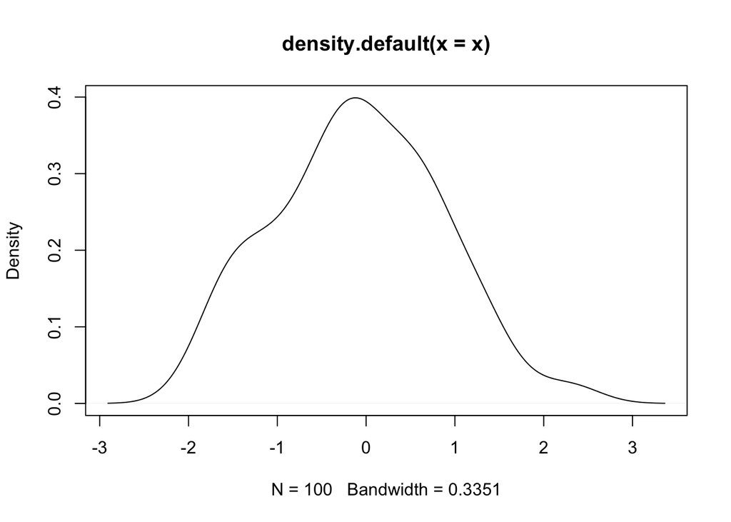

```r
plot(dens)            # plot density
```

Now you try it. For example, take the built-in data set `cars`, which lists speed and stopping distance for cars from the 1920. Plot speed vs. distance, and/or perform a correlation analysis. Then write a few sentences describing what you see.

Plot of speed vs. distance:

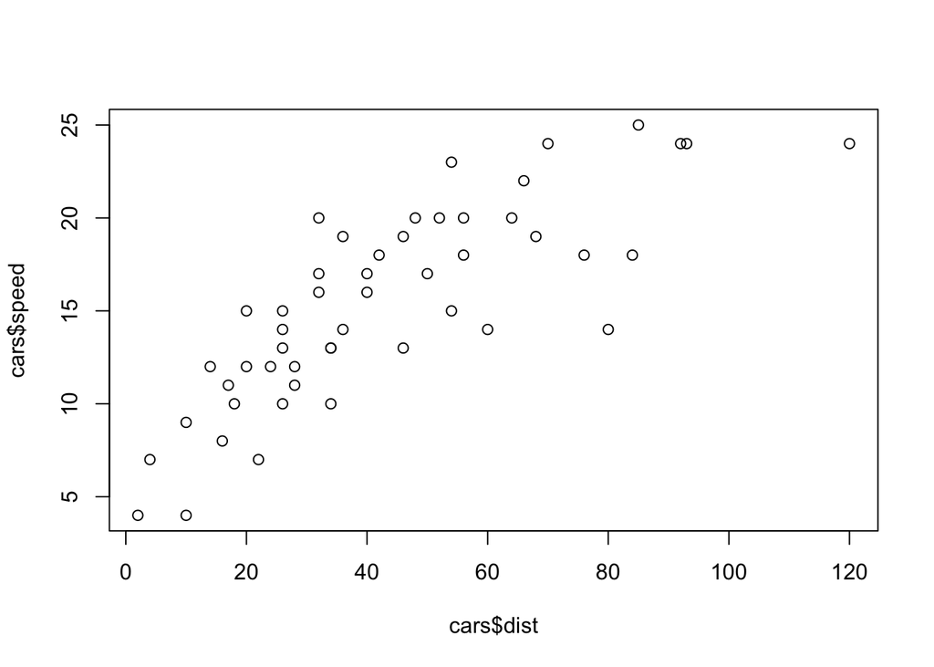

```r
plot(cars$dist, cars$speed)
```

Correlation analysis:

```r
cor.test(cars$dist, cars$speed)
```

```
##
##  Pearson's product-moment correlation
##
## data:  cars$dist and cars$speed
## t = 9.464, df = 48, p-value = 1.49e-12
## alternative hypothesis: true correlation is not equal to 0
## 95 percent confidence interval:
##  0.6816422 0.8862036
## sample estimates:
##       cor
## 0.8068949
```

There is a strong positive correlations. Cars with higher speed have longer stopping distances.